Lung Cancer Analysis

Data as of August 24, 2026 | Analysis run on October 31, 2026

Theme:

## **Analysis Overview**

**Background**

Survival outcomes are an important endpoint in lung cancer research. This analysis uses the `lung` dataset from the [R survival package](https://CRAN.R-project.org/package=survival) to demonstrate descriptive and survival analysis methods in a reproducible HTML report.

**Objective**

To describe participant characteristics and evaluate whether survival differs between participants aged <65 years and those aged ≥65 years.

**Population**

The analysis includes 228 participants with advanced lung cancer. Participants were categorized into two age groups: <65 years and ≥65 years. Survival time was measured from study entry until death or censoring.

## **Descriptive Analysis**

### Summary Table

The analysis included 228 participants, with 128 aged <65 years and 100 aged ≥65 years.

Sex distribution and weight loss were similar between age groups (P=0.103 and P=0.389, respectively).

ECOG performance status differed between age groups (P=0.021), with participants aged ≥65 years more frequently represented in the higher ECOG categories.

No statistical comparison was performed for age because age was used to define the age groups.

Participant Demographic and Clinical Characteristics, Overall and by Age Group

| Characteristics | Overall (N=228) | Age Group >=65 (N=100) | Age Group <65 (N=128) | P-value |
| --- | --- | --- | --- | --- |
| Age (yrs) |  |  |  | — |
| Mean (SD) | 62.4 (9.1) | 70.7 (3.9) | 56.0 (6.3) |  |
| Median (Min, Max) | 63.0 (39.0, 82.0) | 70.0 (65.0, 82.0) | 57.0 (39.0, 64.0) |  |
| Sex |  |  |  | 0.103 |
| Male | 138 (60.5%) | 67 (67.0%) | 71 (55.5%) |  |
| Female | 90 (39.5%) | 33 (33.0%) | 57 (44.5%) |  |
| ECOG Performance Status |  |  |  | 0.021 |
| Fully active | 63 (27.8%) | 22 (22.0%) | 41 (32.3%) |  |
| Restricted but ambulatory | 113 (49.8%) | 47 (47.0%) | 66 (52.0%) |  |
| Ambulatory but unable to work | 50 (22.0%) | 30 (30.0%) | 20 (15.7%) |  |
| Limited self-care | 1 (0.4%) | 1 (1.0%) | 0 (0.0%) |  |
| Missing | 1 | 0 | 1 |  |
| Weight Loss (lbs) |  |  |  | 0.389 |
| Mean (SD) | 9.8 (13.1) | 9.8 (11.3) | 9.9 (14.5) |  |
| Median (Min, Max) | 7.0 (-24.0, 68.0) | 7.0 (-24.0, 38.0) | 5.0 (-15.0, 68.0) |  |
| Missing | 14 | 5 | 9 |  |

Notes:  
Continuous variables are summarized as mean (SD) and median (min, max).  
Categorical variables are summarized as count (%).  
Missing values are displayed but were excluded from statistical analyses.  
P-values compare characteristics between participants aged <65 and ≥65 years and were calculated using the chi-square/Fisher’s exact test for categorical variables and the Kruskal–Wallis test for continuous variables.  
No p-value is reported for age because the age groups were defined directly from age.  
Report based on data submitted through August 24, 2026.

### ECOG Distribution

The distribution of ECOG performance status differed significantly between age groups (P=0.021).

Participants aged ≥65 years had a higher proportion of Ambulatory but unable to work (30.0% vs. 15.7%) and a lower proportion of Fully active (22.0% vs. 32.3%) compared with those aged <65 years.

These findings suggest poorer baseline functional status among older participants.

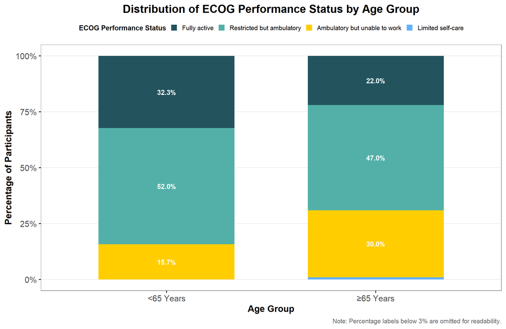

## **Survival Analysis**

### Kaplan-Meier Estimates

Kaplan–Meier analysis is a nonparametric method used to estimate survival probability over time while accounting for censored observations. In this analysis, death was the event of interest, and participants who did not experience death during follow-up were censored. Kaplan–Meier curves were used to estimate and visualize survival for participants aged <65 years and ≥65 years. The log-rank test was used to compare the overall survival distributions between the two age groups.

Survival probability decreased over time in both age groups.

At 6 months, estimated survival was 72.3 (65.0, 80.6)% in participants aged <65 years and 68.8 (60.3, 78.6)% in participants aged ≥65 years.

At 1 year, estimated survival was 46.0 (37.4, 56.6)% and 34.7 (25.9, 46.6)%, respectively.

At 2 years, estimated survival was 15.6 (8.9, 27.2)% and 7.3 (3.0, 17.8)%, respectively.

The log-rank test did not provide evidence of a statistically significant difference in the overall survival distributions between the two age groups (P-value =0.055).

Kaplan–Meier Estimates of Lung Cancer Survival by Age Group

| Time | Age Group <65 Years N at Risk | Age Group <65 Years Survival (95% CI) | Age Group ≥65 Years N at Risk | Age Group ≥65 Years Survival (95% CI) |
| --- | --- | --- | --- | --- |
| Baseline | 128 | 100.0 (100.0, 100.0) | 100 | 100.0 (100.0, 100.0) |
| 6 Months | 89 | 72.3 (65.0, 80.6) | 67 | 68.8 (60.3, 78.6) |
| 1 Year | 39 | 46.0 (37.4, 56.6) | 26 | 34.7 (25.9, 46.6) |
| 2 Years | 9 | 15.6 (8.9, 27.2) | 4 | 7.3 (3.0, 17.8) |

Notes:  
N at risk represents the number of participants remaining at risk of death immediately before each time point.  
Survival probabilities and confidence intervals are presented as percentages, and were estimated using the Kaplan–Meier method.  
Report based on data submitted through August 24, 2026.

### Cox PH

Cox proportional hazards regression is a survival analysis method used to evaluate the association between one or more predictors and the hazard of experiencing an event over time. Results are expressed as hazard ratios (HRs). An HR greater than 1 indicates a higher hazard of the event relative to the reference group, while an HR less than 1 indicates a lower hazard. In this analysis, participants aged <65 years were used as the reference group.

Participants aged ≥65 years had an estimated 35% higher hazard of death compared with participants aged <65 years (HR=1.35, 95% CI: 0.99–1.83; P=0.056). The confidence interval included 1 and the P-value was greater than 0.05, indicating that the association was not statistically significant. The proportional hazards assumption showed no evidence of violation (P=0.786).

Cox Proportional Hazards Model for Lung Cancer Survival by Age Group

| Comparison | HR | 95% CI | P-value |
| --- | --- | --- | --- |
| ≥65 vs <65 | 1.35 | 0.99–1.83 | 0.056 |

Notes:  
HR = hazard ratio; CI = confidence interval.  
Participants aged <65 years were the reference group.  
An HR >1 indicates a higher hazard of death compared with the reference group.  
The proportional hazards assumption was assessed using Schoenfeld residuals and showed no evidence of violation (P=0.786).  
Report based on data submitted through August 24, 2026.